# Water Column and Sediment Methanogens & Methanotrophs in FPV Ponds

Sophia Aredas & Mar Schmidt

22 August, 2026

# Purpose

We will create a figure to show the difference in methanogens and methanotrophs in FSP and control ponds at different depths and between sample types.

Additionally, I have written the methods and results in this document which will be added to the google document.

# Load packages

```r
# Efficiently load packages
pacman::p_load(ggplot2, phyloseq, ggpubr, tidyverse, patchwork, ggh4x, speedyseq, rstatix, dplyr, purrr, vegan, ANCOMBC, microViz,cowplot, grid, scales, Biostrings, stringr, lmerTest, ggtext, install = TRUE)

source("code/functions.R") # contains scale_reads
source("code/colors_and_shapes.R")

# Set our seed for reproducibility
set.seed(09091999)
```

# Load in Data

Loading in our .RData objects. This has now has 16S rRNA abundances normalized by picrust2

1. Water samples have flow cytometry derived absolute abundances.
2. Sediments do not have absolute abundance measurements incorporated. Instead, it has been scaled down to the minimum reads. Note: we scale down to the minimum number of reads to standardize/normalize our data to allow for more accurate comparisons between reads to account for uneven sequencing depth across samples (may arise to do sequencing runs or library prep efficiency, etc.)

And we will add in our metadata as well!

```r
# or we can also load in water physeq that has absolute abundance as well
load("data/00_load_data/water_physeq.RData")

# sediment scaled physeq
load("data/00_load_data/scaled_sed_physeq.RData")

## Add JDate to the sample_data
sample_data(scaled_sed_physeq)$JDate <-
  lubridate::yday(sample_data(scaled_sed_physeq)$Date_Collected)

# add picrust2 normalized 16s abundances, note water abundances are not absolute yet
load("data/00_load_data/normalized_water_sed_physeq.RData")

# physeq with water (unincorporated cell counts) + sediment samples = 188 samples total
# load("data/00_load_data/new_archaea_rooted_physeq.RData")

## Add JDate to the sample_data
sample_data(normalized_water_sed_physeq)$JDate <-
  lubridate::yday(sample_data(normalized_water_sed_physeq)$Date_Collected)

# load in metadata
load("data/00_load_data/meta_track_23_24.RData")
metadata <- meta_track_23_24
```

# Prepare Phyloseq Objects

Here we will work with our two sample types (water and sediment) for the entire 2024 year.

### Water

First we will filter out our water samples and save it as a phyloseq object and data frame

```r
# filter for all time points in 2024
water_physeq_24 <- subset_samples(water_physeq, Year == "2024")

# prune taxa
water_physeq_24 <- water_physeq_24 %>%
  prune_taxa(taxa_sums(.) > 0,.)

# melt physeq into data frame for all taxa
water_physeq_ch4_df <- water_physeq_24 %>%
  speedyseq::psmelt() # melt into dataframe
```

We have created: 1. `water_physeq_24` phyloseq object of just 2024 water samples 2. `water_physeq_ch4_df` data frame from water physeq

### Sediment

Filter out sediment samples and save it as a phyloseq object and data frame. Same as the water samples we will filter out our phyloseq object and save it.

```r
# filter phyloseq for only sediment samples
sed_phy <- subset_samples(normalized_water_sed_physeq, SampleType == "Sediment")

# subset samples
sed_physeq <- subset_samples(sed_phy, !(sample_names(sed_phy) %in% c("SA_D046", "SA_D047")))

# prune taxa
sed_phy <- sed_physeq %>%
  prune_taxa(taxa_sums(.) > 0,.)

# Intuition check of number of sequences per sample
min(sample_sums(sed_phy)) ## min = 18812.56
```

```
## [1] 18812.56
```

```r
# scale water_physeq to minimum number of reads
scaled_sed_physeq <-
  sed_phy %>%
  scale_reads(round = "matround")

# melt physeq into data frame for all time points
scaled_sed_physeq_24 <- scaled_sed_physeq

# pull unique methane cycler taxonomic information
scaled_sed_24_df <- scaled_sed_physeq_24 %>%
  speedyseq::transform_sample_counts(function(x) x/sum(x)) %>% # transform to relative abundance here
  speedyseq::psmelt()  # melt into dataframe

# save phyloseq object
save(scaled_sed_24_df, file = "data/01_phyloseq/scaled_sed_24_df.RData")
```

We have created: 1. `scaled_sed_physeq_24` phyloseq object of sediment samples that have been rarified to minimum sequencing depth 2. `scaled_sed_24_df` melted sediment physeq data frame that has been transformed to relative abundance

# FAPROTAXv2 - Predict Metabolic Functions (CH4 Cyclers)

Now that we have saved our phyloseq objects from our water and sediment samples, we will be using FAPROTAXv2 to identify which ASVs are methanotrophs or methanogens.

This is different from the original FAPROTAXv1 which uses taxonomic identification based on the SILVA database. Although it does understand GreenGenes2 naming, with the updated GreenGenes2 taxonomic identification, it does predict less than if we had used SILVA which makes sense since it is now incorporating taxonomic identities to unify metagenomic and amplicon sequencing studies.

Instead we will be using FAPROTAXv2’s function to take the representative 16S rRNA sequences and place it on a phylogenetic tree using a reference tree to functionally predict ASVs. We will then take those ASVs and integrate it with our taxonomy table to see who is identified as what, preferably at the genus level.

### Water - Create FASTA File

Here we will start with a classic OTU table in TSV format but without taxonomic identities. Instead we will have 16S rRNA sequences in a fasta format to place OTUs on FAPROTAX reference tree and functionally annotate from there

```r
# set seed
set.seed(09091999)

# 1. Create otu table
classic_otu_table_water <- water_physeq_24 %>%
  otu_table %>%
  psmelt() %>%
  pivot_wider(names_from = Sample, values_from = Abundance)

write_tsv(classic_otu_table_water, file = paste0("data/02A_Water_FAPROTAXv2/water_otu_table.tsv"))

# create fasta file
otu_water_24 <- psmelt(water_physeq_24) %>%
  dplyr::select(OTU, Kingdom:ASVseqs) %>%
    distinct(OTU, .keep_all = TRUE) %>% # i think one unique otu is fine?
  mutate(taxonomy = paste(Kingdom, Phylum, Class, Order, Family, sep=";")) %>%
  dplyr::select(OTU,ASVseqs)


# use biostrings to create fasta file
dna_seqs <- DNAStringSet(otu_water_24$ASVseqs)
names(dna_seqs) <- otu_water_24$OTU
writeXStringSet(dna_seqs, "data/02A_Water_FAPROTAXv2/water_16S_seqs.fasta")

# intuition check, no news is good news
# Check if OTU IDs match between the two files
otu_ids_table <- otu_water_24$OTU
otu_ids_fasta <- names(dna_seqs)

identical(sort(otu_ids_table), sort(otu_ids_fasta)) # check id table
```

```
## [1] TRUE
```

```r
stopifnot(identical(names(dna_seqs), otu_water_24$OTU)) # check that fasta df is good, no news is good news
```

Now that we have created our .fasta file from our water samples, we can now run FAPROTAXv2 on them to functionally predict.

### Water - Run FAPROTAXv2

First we will align our sequences to the reference sequences using mafft.

```bash
# move directory
cd data/02A_Water_FAPROTAXv2

# get mafft onto path -- make sure to copy this in terminal
export PATH=/programs/mafft/bin:$PATH


# align our 16S rRNA fasta list to FAPROTAX2 database reference OR align through mafft GUI website if crashing
/programs/mafft/bin/mafft --auto --addfragments water_16S_seqs.fasta --thread -12 --keeplength SILVA_FOCAL_ALIGNMENTS_SANITIZED_SUBSET.fasta > water_output_alignment.fasta

# gui website code that was run
mafft --thread 12 --inputorder --keeplength --anysymbol --maxambiguous 0.0 --addfragments fragments --auto input > output

# run script to functionally annotate
# since we have already created alignment we place our aligned sequences in already and no need to add reference file

# run script to create phylogenetic tree
# first set environment to have epa-ng to create tree
export LD_LIBRARY_PATH=/usr/local/gcc-7.3.0/lib64:/usr/local/gcc-7.3.0/lib
export PATH=/programs/epa-ng-0.3.8/bin:$PATH
export LD_LIBRARY_PATH=/usr/lib64:$LD_LIBRARY_PATH # was having issues for getting Rcpp to work but this got it to go!

# run script with aligned mafft aligned fasta file and tree
# running with default for now which uses the binomial hsp algorithm
Rscript faprotax.R -i water_otu_table.tsv -a water_16s_alignment.fasta -o ch4_water_function_table_16S_1new.tsv --out_intermediates ch4_water_intermediates3 -d /local//workdir/sna49/FS_CH4_Mech_Ray_LO_Letters/data/02A_Water_FAPROTAXv2 -r ch4_water_report3.txt  --otu_names_are_in_column "OTU" --hsp_algorithm "binomial"
```

### Water - Extract Predicted FAPROTAXv2 Results

Now we will get our function table and find the predicted metabolic functions that correspond to methane cycling, methanogens or methanotrophs. It will provide the ASV as well as the predicted function.

First we will extract all functions then narrow in on CH4 cyclers. This will also be paired with taxonomic identification of known methane cyclers at the genus level.

ASVs not classified to the family or genus level were filtered out from analysis despite FAPROTAXv2 predictions.

Each ASV will be verified through literature review to ensure it is a known methanogen or methanotroph

```r
# Read the text file of faprotaxv2 report from the previous chunk!
lines <- readLines("data/02A_Water_FAPROTAXv2/ch4_water_report3.txt")

# create empty vectors
function_group <- c()
asv_ids <- c()

# temporary variable to store current function name
current_function <- NA

for (line in lines) {
  line <- str_trim(line)

  # function group name
  if (str_detect(line, ":$")) {
    current_function <- str_extract(line, "^[^\\s(]+")  # gets function name before the space
  }

  # reads asv lines (i.e. ASV_8 (P = 1))
  if (str_detect(line, "^ASV_\\d+")) {
    asv_id <- str_extract(line, "ASV_\\d+")
    function_group <- c(function_group, current_function)
    asv_ids <- c(asv_ids, asv_id)
  }
}

# Combine into dataframe
asv_df <- data.frame(function_group, asv_id = asv_ids)

# View if curious!
#View(asv_df)


# now lets specifically pull out the ch4 cyclers
water_ch4_cyclers_asv_df <- asv_df %>%
  dplyr::filter(function_group %in% c(
                "acetoclastic_methanogenesis.value",
                "hydrogenotrophic_methanogenesis.value",
                "methanogenesis_by_CO2_reduction_with_H2.value",
                "methanogenesis_by_disproportionation_of_methyl_groups.value",
                "methanogenesis_by_reduction_of_methyl_compounds_with_H2.value",
                "methanogenesis_using_formate.value",
                "methanogenesis.value",
                "methanotrophy.value")) #%>%
  # dplyr::mutate(
  #   CH4_Cycler = dplyr::case_when(
  #     grepl("methanogenesis", function_group) ~ "Methanogen",
  #     grepl("methanotrophy", function_group) ~ "Methanotroph",
  #     TRUE ~ NA_character_))

# quick check to see if we have any duplicated asvs
duplicates <- water_ch4_cyclers_asv_df %>%
  dplyr::group_by(asv_id) %>%
  dplyr::summarise(
    n_function_groups = dplyr::n_distinct(function_group), # number of function groups
    function_groups = paste(unique(function_group), collapse = ", ") # if theres another one where asv is duplicated
  ) %>%
  dplyr::filter(n_function_groups > 1) # count
duplicates # awesome methanogenesis functions overlap
```

```
## # A tibble: 61 × 3
##    asv_id    n_function_groups function_groups
##    <chr>                 <int> <chr>
##  1 ASV_102                   3 methanogenesis_by_CO2_reduction_with_H2.value, methanogenesis_using_formate.value, methanogenesis.value
##  2 ASV_1063                  4 hydrogenotrophic_methanogenesis.value, methanogenesis_by_CO2_reduction_with_H2.value, methanogenesis_by_reduction_of_methyl_compounds_with_H2.value, methanogenesis.value
##  3 ASV_1130                  3 methanogenesis_by_CO2_reduction_with_H2.value, methanogenesis_using_formate.value, methanogenesis.value
##  4 ASV_11495                 4 hydrogenotrophic_methanogenesis.value, methanogenesis_by_CO2_reduction_with_H2.value, methanogenesis_using_formate.value, methanogenesis.value
##  5 ASV_1308                  3 methanogenesis_by_CO2_reduction_with_H2.value, methanogenesis_using_formate.value, methanogenesis.value
##  6 ASV_13661                 3 methanogenesis_by_CO2_reduction_with_H2.value, methanogenesis_using_formate.value, methanogenesis.value
##  7 ASV_1399                  4 acetoclastic_methanogenesis.value, methanogenesis_by_CO2_reduction_with_H2.value, methanogenesis_by_disproportionation_of_methyl_groups.value, methanogenesis.value
##  8 ASV_14                    2 acetoclastic_methanogenesis.value, methanogenesis.value
##  9 ASV_165                   3 hydrogenotrophic_methanogenesis.value, methanogenesis_by_CO2_reduction_with_H2.value, methanogenesis.value
## 10 ASV_17520                 4 hydrogenotrophic_methanogenesis.value, methanogenesis_by_CO2_reduction_with_H2.value, methanogenesis_using_formate.value, methanogenesis.value
## # ℹ 51 more rows
```

```r
# methanogens have multiple annotations but they are all methanogenesis, we will keep the first occurrence of each asv since the specific function subtype doesnt matter to much to me right now
water_ch4_cyclers_asv_unique <- water_ch4_cyclers_asv_df %>%
  dplyr::distinct(asv_id, .keep_all = TRUE)

# join ch4 cyclers with water_physeq_ch4_df
water_ch4_joined <- water_physeq_ch4_df %>%
  dplyr::inner_join(water_ch4_cyclers_asv_unique,
                    by = c("ASV" = "asv_id")) # 11712 observations!

# tidy up dataframe
water_ch4_joined <- water_ch4_joined %>%
  dplyr::select(function_group, Kingdom, Phylum, Class, Order,
                Family, Genus, Species, ASV, ASVseqs)


# check out unqiue taxanomic levels
water_ch4_joined$Phylum %>% unique()
```

```
## [1] "Pseudomonadota"           "Halobacteriota"           "Verrucomicrobiota"        "Methanobacteriota_A_1229" "Methanobacteriota_B"
```

```r
water_ch4_joined$Order %>% unique()
```

```
##  [1] "Methylococcales"          "Rhizobiales_505101"       "Methanotrichales"         "Methanomicrobiales"       "Methylacidiphilales"      "Methanobacteriales"       NA                         "Burkholderiales"          "Enterobacterales_737866"
## [10] "Azospirillales_507929"    "Methanocellales"          "Methanosarcinales_A_2632" "Methanofastidiosales"     "Xanthomonadales"
```

```r
water_ch4_joined$Genus %>% unique()
```

```
##  [1] "Methylomonas"            NA                        "Methyloparacoccus"       "Methylobacter_C_601751"  "Methylocystis"           "Methylosoma"             "Methanothrix_B"          "Methanoregula"           "UBA3015"
## [10] "UBA4132"                 "Methylococcus"           "GAS474"                  "JAAUTS01"                "Methanobacterium_B_963"  "LW23"                    "Methyloterricola"        "Methylobacter_C_601048"  "Methanobacterium_A"
## [19] "Methanospirillum"        "Derxia"                  "Methylotetracoccus"      "UBA467"                  "Methylomagnum"           "Methanobacterium_D_1054" "Methanolinea_A"          "Methanosphaera"          "Methyloglobulus"
## [28] "Methylovulum"            "Azospirillum"            "Methanobrevibacter_D"    "Crenothrix"              "Methanobacterium_F_900"  "Methanocella_A"          "Methanosarcina_2619"     "Methanofastidiosum"      "Tahibacter"
```

```r
water_ch4_joined$ASV %>% unique()
```

```
##   [1] "ASV_44"    "ASV_13"    "ASV_32"    "ASV_119"   "ASV_930"   "ASV_357"   "ASV_141"   "ASV_498"   "ASV_294"   "ASV_465"   "ASV_468"   "ASV_177"   "ASV_4105"  "ASV_679"   "ASV_415"   "ASV_54"    "ASV_5160"  "ASV_3795"  "ASV_14"    "ASV_376"
##  [21] "ASV_493"   "ASV_559"   "ASV_1308"  "ASV_4041"  "ASV_822"   "ASV_2664"  "ASV_3053"  "ASV_1600"  "ASV_2021"  "ASV_951"   "ASV_286"   "ASV_340"   "ASV_346"   "ASV_1063"  "ASV_1115"  "ASV_2286"  "ASV_1396"  "ASV_4242"  "ASV_1233"  "ASV_976"
##  [41] "ASV_400"   "ASV_517"   "ASV_1008"  "ASV_4563"  "ASV_363"   "ASV_656"   "ASV_6047"  "ASV_5855"  "ASV_940"   "ASV_4211"  "ASV_971"   "ASV_1051"  "ASV_4168"  "ASV_352"   "ASV_4099"  "ASV_2200"  "ASV_7055"  "ASV_4990"  "ASV_110"   "ASV_1384"
##  [61] "ASV_1252"  "ASV_3231"  "ASV_1479"  "ASV_1801"  "ASV_1271"  "ASV_1755"  "ASV_1357"  "ASV_4861"  "ASV_4723"  "ASV_4564"  "ASV_2530"  "ASV_499"   "ASV_4006"  "ASV_302"   "ASV_642"   "ASV_3075"  "ASV_231"   "ASV_13661" "ASV_1855"  "ASV_2432"
##  [81] "ASV_13808" "ASV_9322"  "ASV_9249"  "ASV_10605" "ASV_7017"  "ASV_1402"  "ASV_216"   "ASV_2205"  "ASV_7080"  "ASV_6300"  "ASV_21570" "ASV_3842"  "ASV_7406"  "ASV_3675"  "ASV_1711"  "ASV_592"   "ASV_12554" "ASV_2424"  "ASV_2551"  "ASV_10495"
## [101] "ASV_1945"  "ASV_7156"  "ASV_10548" "ASV_4112"  "ASV_434"   "ASV_8513"  "ASV_31783" "ASV_4270"  "ASV_1449"  "ASV_5235"  "ASV_10767" "ASV_5236"  "ASV_33483" "ASV_45107" "ASV_2436"  "ASV_1693"  "ASV_6110"  "ASV_11495" "ASV_10712" "ASV_12143"
## [121] "ASV_28739" "ASV_8748"  "ASV_9712"  "ASV_8273"  "ASV_8447"  "ASV_15902" "ASV_5180"  "ASV_2677"  "ASV_3601"  "ASV_36017" "ASV_16436" "ASV_8851"  "ASV_853"   "ASV_568"   "ASV_9644"  "ASV_39294" "ASV_3329"  "ASV_38296" "ASV_38299" "ASV_102"
## [141] "ASV_3305"  "ASV_3663"  "ASV_2964"  "ASV_7355"  "ASV_2028"  "ASV_6701"  "ASV_6648"  "ASV_4541"  "ASV_12642" "ASV_6560"  "ASV_30344" "ASV_650"   "ASV_3467"  "ASV_6126"  "ASV_1920"  "ASV_7536"  "ASV_16387" "ASV_19979" "ASV_10120" "ASV_23345"
## [161] "ASV_1130"  "ASV_165"   "ASV_20915" "ASV_20873" "ASV_14949" "ASV_431"   "ASV_25231" "ASV_9569"  "ASV_11115" "ASV_2358"  "ASV_5923"  "ASV_25349" "ASV_4503"  "ASV_37395" "ASV_6164"  "ASV_8036"  "ASV_11915" "ASV_7195"  "ASV_31812" "ASV_8955"
## [181] "ASV_29215" "ASV_11514" "ASV_16078" "ASV_2783"  "ASV_12500" "ASV_20303" "ASV_20251" "ASV_15160" "ASV_6606"  "ASV_30308" "ASV_11074" "ASV_27149" "ASV_11700" "ASV_21347" "ASV_29197" "ASV_18287" "ASV_32507" "ASV_4087"  "ASV_17147" "ASV_33250"
## [201] "ASV_580"   "ASV_24837" "ASV_37854" "ASV_21338" "ASV_13258" "ASV_11517" "ASV_23042" "ASV_28359" "ASV_26767" "ASV_21382" "ASV_33167" "ASV_33519" "ASV_4051"  "ASV_33533" "ASV_7324"  "ASV_17520" "ASV_34133" "ASV_10257" "ASV_11913" "ASV_42413"
## [221] "ASV_36504" "ASV_4382"  "ASV_44524" "ASV_1809"  "ASV_10277" "ASV_23076" "ASV_29492" "ASV_32538" "ASV_3892"  "ASV_884"   "ASV_5812"  "ASV_45729" "ASV_45799" "ASV_8424"  "ASV_44715" "ASV_44495" "ASV_29697" "ASV_32172" "ASV_6851"  "ASV_321"
## [241] "ASV_1399"  "ASV_44094" "ASV_38964" "ASV_14329"
```

```r
# filter out NA at order level
water_ch4_joined <- water_ch4_joined %>%
  dplyr::filter(!is.na(Family)) # 10992

# create dataframe for sipmlified distinct ASV to verify
simplified_af <- water_ch4_joined %>%
  distinct(Genus, .keep_all = TRUE)
simplified_af
```

```
##                                   function_group  Kingdom                   Phylum               Class                    Order                    Family                   Genus       Species       ASV
## 1                            methanotrophy.value Bacteria           Pseudomonadota Gammaproteobacteria          Methylococcales         Methylomonadaceae            Methylomonas         albis    ASV_44
## 2                            methanotrophy.value Bacteria           Pseudomonadota Gammaproteobacteria          Methylococcales         Methylomonadaceae                    <NA>          <NA>    ASV_13
## 3                            methanotrophy.value Bacteria           Pseudomonadota Gammaproteobacteria          Methylococcales          Methylococcaceae       Methyloparacoccus          <NA>    ASV_32
## 4                            methanotrophy.value Bacteria           Pseudomonadota Gammaproteobacteria          Methylococcales         Methylomonadaceae  Methylobacter_C_601751          <NA>   ASV_141
## 5                            methanotrophy.value Bacteria           Pseudomonadota Alphaproteobacteria       Rhizobiales_505101          Beijerinckiaceae           Methylocystis          <NA>   ASV_465
## 6                            methanotrophy.value Bacteria           Pseudomonadota Gammaproteobacteria          Methylococcales         Methylomonadaceae             Methylosoma          <NA>   ASV_679
## 7              acetoclastic_methanogenesis.value  Archaea           Halobacteriota     Methanosarcinia         Methanotrichales         Methanotrichaceae          Methanothrix_B    soehngenii   ASV_415
## 8  methanogenesis_by_CO2_reduction_with_H2.value  Archaea           Halobacteriota     Methanomicrobia       Methanomicrobiales  Methanospirillaceae_2121           Methanoregula   sp002502245    ASV_54
## 9                            methanotrophy.value Bacteria        Verrucomicrobiota    Verrucomicrobiae      Methylacidiphilales                   UBA3015                 UBA3015   sp001438005  ASV_3795
## 10                           methanotrophy.value Bacteria           Pseudomonadota Gammaproteobacteria          Methylococcales         Methylomonadaceae                 UBA4132   sp002134785   ASV_493
## 11                           methanotrophy.value Bacteria           Pseudomonadota Gammaproteobacteria          Methylococcales          Methylococcaceae           Methylococcus    capsulatus   ASV_822
## 12                           methanotrophy.value Bacteria        Verrucomicrobiota    Verrucomicrobiae      Methylacidiphilales                    GAS474                  GAS474          <NA>  ASV_3053
## 13                           methanotrophy.value Bacteria        Verrucomicrobiota    Verrucomicrobiae      Methylacidiphilales                  JAAUTS01                JAAUTS01   sp012031345  ASV_1600
## 14         hydrogenotrophic_methanogenesis.value  Archaea Methanobacteriota_A_1229     Methanobacteria       Methanobacteriales       Methanobacteriaceae  Methanobacterium_B_963         lacus  ASV_1063
```

[output cut: 59 more lines]

```r
# now comparing with literature who is identified as a ch4 cycler
# filtering out incorrectly identified asvs, or asvs with no literature supporting their predicted metabolic function
water_ch4_joined_clean_faprotax <- water_ch4_joined %>%
  dplyr::filter(
    !Genus %in% c(
    "Derxia", "UBA10450", "UBA11358", "Alsobacter", "UBA3015", "GAS474", "JAAUTS01",
    "UBA6215", "LW23", "WYBW01", "Pedosphaera", "Azospirillum", "YA12-FULL-60-10",
    "Beijerinckia", "SXTU01", "AV2", "Lenti-01", "PWTM01", "UBA95"),
    !Family %in% c("J093", "UBA10450", "Rhodanobacteraceae"),
    !ASV %in% c("ASV_468")) # total 9744

water_ch4_joined_clean_faprotax$Family %>% unique()
```

```
##  [1] "Methylomonadaceae"        "Methylococcaceae"         "Beijerinckiaceae"         "Methanotrichaceae"        "Methanospirillaceae_2121" "Methanobacteriaceae"      "Methanospirillaceae_2125" "Methanomicrobiaceae"      "Methanocellaceae"
## [10] "Methanosarcinaceae"       "Methanofastidiosaceae"
```

```r
# notes for my exclusions:
# 1. cannot find any information for derxia being methanotroph
# 2. UBA10450 (family) is within Chthoniobacterales (order) within Verrucomicrobiota. since this is at family level its hard to say what is function is. im finding its involved in complex carbon degradation and could maybe be a methanotroph and have other pathways to break this down but with this uncertainty and especially since no genus level identification will omit for now. most are apparently aerobic/anaerobic chemoorganotrophs
  # verruco methanotrophs are within methylacidiphilaceae family https://www.mdpi.com/2076-2607/12/11/2271
# 3. UBA11358 (family and genus) within Verrucomicrobiota i cant find solid evidence for methanotrophy either but based on these MAGs seems they are involved in other h2 metabolisms and stuff; biorxiv https://www.biorxiv.org/content/10.1101/2024.07.02.601631v1
# 4. aslobacter soli is a chemo-organotroph incapable of growth on C1 substrates [https://www.microbiologyresearch.org/content/journal/ijsem/10.1099/ijsem.0.003088#R1]
# 5. Methylacidiphilales (order), UBA3015 (family), UBA3015 (genus). not methanotroph likely heterotroph invovled in plant degradation. [https://registry.seqco.de/names/48695; https://www.nature.com/articles/s41467-025-63266-9]
# 6. GAS474 lacks genes for methanotrophy likely methylotroph or complex carbon degrader [https://www.nature.com/articles/s41522-024-00583-9]
# 7. JAAUTS01 no evidence for known methanotrophy
# 8. UBA6215 within Omnitrophota are not known to be methanotrophs but have diverse metabolic capabilities like acetogenesis and potentially parasitic? [https://www.nature.com/articles/s41564-022-01319-1]
# 9. LW23 likely methylotroph [https://www.mdpi.com/2076-2607/9/12/2566?utm_source=researchgate.net&medium=article]
# 10. WYBW01 methylotroph [https://www.biorxiv.org/content/10.1101/2025.02.12.637893v3.full]
# 11. Pedosphaera no evidence for methanotrophy
# 12. Azospirillum is a methylotroph, no evidence for methanotrophy [https://www.nature.com/articles/s43247-024-01656-5]
# 13. YA12-FULL-60-10 no evidence for methanotrphy [https://www.mdpi.com/2076-2607/8/6/920?utm_source=researchgate.net&medium=article]
# 14. Beijerinckia chemoheterotroph, not capable of methylotrophic or methanotrophy. [https://journals.asm.org/doi/10.1128/jb.00656-10]
# 15. SXTU01 not known methanotroph, no literature supporting this or found
# 16. AV2, no evidence for methanotrophy
# 17. Lenti-01, no evidence for methanotrophy. specialists for degrading sulfated polysaccharides [https://pmc.ncbi.nlm.nih.gov/articles/PMC8857213/#:~:text=A%20phylogenetic%20reconstruction%20using%20conserved,also%20determined%20(Supplementary%20results).]
# 18. PWTM01 no reports of methanotrophy
# 19. UBA95 could not find support for methanogenesis, seems to have other metabolic capabilities like secondary metabolites and nitrogen cycling.
# 20. JO93 not methanotroph likely, in different order with that doesnt have known methanotrophs
# 21. removing ASVs within Beijerinckiaceae family that are NA at genus level as not all genera are capable of methanotrophy


# distinct at family level for ch4 cycler
# one NA at genus but family is all known methanotrophs
# these are just intuition checks!
water_ch4_joined_clean_faprotax$Order %>% unique()
```

```
## [1] "Methylococcales"          "Rhizobiales_505101"       "Methanotrichales"         "Methanomicrobiales"       "Methanobacteriales"       "Methanocellales"          "Methanosarcinales_A_2632" "Methanofastidiosales"
```

```r
faprotaxv2_family <- unique(water_ch4_joined_clean_faprotax$Family)


# now lets create data frame to search in case faprotax missed a literature-based identified methanotroph
water_24_taxonomysearch <- water_physeq_ch4_df %>%
  dplyr::select(OTU, Kingdom:ASVseqs) %>%
  distinct(OTU, .keep_all = TRUE) %>% # one ASV per row
  dplyr::filter(!is.na(Family)) # cannot be na and family level and below


# rationale to include this above:
  #1. 2-02-FULL-66-22 contains nitrite-dependent anaerobic methane oxidizing (N-DAMO) bacteria that couple anaerobic methane oxidation to nitrite reduction.
  #2. Methanomethylophilaceae within Methanomassiliicoccales is a methanogen

# additional information from searching:
  #1. UBA12499 within Rokubacteriales in Methylomirobiota is a methylotroph, no known genes to oxidize methane.


# create dataframes for manual search
water_24_manual <- water_24_taxonomysearch %>%
  dplyr::filter(Family %in% c("2-02-FULL-66-22", "Methanomethylophilaceae", "UBA472",
                              "Methanomassiliicoccaceae", "Methylomonadaceae", "Methanobacteriaceae") |
                Order %in% c("Methylococcales") |
                  Genus %in% c("Methylocella"))# %>%
  #dplyr::filter
  # family level to also include manually (e.g., specific N-DAMO methanotroph and methanogen
  #dplyr::distinct(ASV, .keep_all = TRUE) # one ASV per row


# finalize dataframe column orders before merging
water_ch4_joined_clean_faprotax_trim <- water_ch4_joined_clean_faprotax %>%
  dplyr::select(-function_group)

water_ch4_manual_trim <- water_24_manual %>%
  dplyr::select(-OTU)


# bind rows
water_ch4_cyclers_complete_df <- dplyr::bind_rows(
  water_ch4_joined_clean_faprotax_trim,
  water_ch4_manual_trim
)

# list of all our CH4 cycler ASVs to filter phyloseq
ch4_asv_list <- water_ch4_cyclers_complete_df$ASV

# filter phyloseq for CH4 cyclers at the ASV level
water_ch4_cyclers_physeq <- water_physeq_24 %>%
  subset_taxa(ASV %in% ch4_asv_list)


# create list of CH4 cylcers at the family level!
water_methanogens <- c("Methanotrichaceae", "Methanospirillaceae_2121", "Methanobacteriaceae",
                 "Methanospirillaceae_2125", "Methanosarcinaceae","Methanocellaceae",
                 "Methanomicrobiaceae", "Methanofastidiosaceae", "Methanomethylophilaceae", "UBA472", "Methanomassiliicoccaceae")
water_methanotrophs <- c("Methylomonadaceae", "Methylococcales","Beijerinckiaceae", "2-02-FULL-66-22")

# # create list of CH4 cylcers at the order level!
# water_ch4_cyclers_complete_df$Order %>% unique()
# water_methanogens_o <- c("Methanotrichaceae", "Methanospirillaceae_2121", "Methanobacteriaceae",
#                  "Methanospirillaceae_2125", "Methanosarcinaceae","Methanocellaceae",
#                  "Methanomicrobiaceae", "Methanofastidiosaceae", "Methanomethylophilaceae", "UBA472", "Methanomassiliicoccaceae")
# water_methanotrophs_o <- c("Methylomonadaceae", "Methylococcaceae","Beijerinckiaceae", "2-02-FULL-66-22")

# add if methanogen or methanotroph to column
tax_tab <- as.data.frame(tax_table(water_ch4_cyclers_physeq))

tax_tab$CH4_Cycler <- dplyr::case_when(
  tax_tab$Family %in% water_methanogens ~ "Methanogen",
  tax_tab$Family %in% water_methanotrophs   ~ "Methanotroph",
  tax_tab$Order %in% water_methanotrophs   ~ "Methanotroph",
  TRUE ~ "NA"
)


tax_table(water_ch4_cyclers_physeq) <- tax_table(as.matrix(tax_tab))

water_ch4_cyclers_physeq # 248 total ASVs
```

```
## phyloseq-class experiment-level object
## otu_table()   OTU Table:          [ 248 taxa and 48 samples ]:
## sample_data() Sample Data:        [ 48 samples by 51 sample variables ]:
## tax_table()   Taxonomy Table:     [ 248 taxa by 10 taxonomic ranks ]:
## phy_tree()    Phylogenetic Tree:  [ 248 tips and 247 internal nodes ]:
## taxa are columns
```

```r
# save phyloseq object
save(water_ch4_cyclers_physeq, file = "data/01_phyloseq/water_ch4_cyclers_physeq.RData")

# melt into dataframe for plotting CH4 cyclers
water_ch4_cyclers_df <- water_ch4_cyclers_physeq %>%
  speedyseq::psmelt() %>%  # melt into dataframe
  dplyr::mutate(
    solar_progress = recode(solar_progress, "FPV" = "FPV", "No FPV" = "Open"), # solar progress
    Depth_Class = recode(Depth_Class,  # depth class
      "S" = "Surface Water",
      "B" = "Bottom Water")) %>%
  dplyr::select(DNA_ID, Abundance, Pond, solar_progress, CH4_Cycler, JDate, Date_Collected, Depth_Class,
                Phylum, Class, Order, Family, Genus, ASV, Species)

# save water CH4 cyclers df as .RData
save(water_ch4_cyclers_df, file = "data/01_phyloseq/water_ch4_cyclers_df.RData")


# write out to excel file
write.csv(water_ch4_cyclers_df, "data/01_phyloseq/water_ch4_cyclers.csv")
```

Here we used FAPROTAXv2 along with manual identification to functionally predict methanogens and methanotrophs in the water column.

We created: 1. **water_ch4_cylers_physeq** phyloseq object that has all 2024 time points and filtered for *only* methane cyclers

2. **water_ch4_cyclers_df** data frame that will be used for plotting that includes total cell counts and reformatted names such as depth and solar treatment. This was also saved as a .csv file called “water_ch4_cyclers.csv”

### Sediment - Create FASTA File

Here we will start with a classic OTU table in TSV format but without taxonomic identities. Instead we will have 16S rRNA sequences in a fasta format to place OTUs on FAPROTAX reference tree and functionally annotate from there

```r
# set seed
set.seed(09091999)

# 1. Create otu table
classic_otu_table_sed <- scaled_sed_physeq %>%
  otu_table %>%
  psmelt() %>%
  pivot_wider(names_from = Sample, values_from = Abundance)

write_tsv(classic_otu_table_sed, file = paste0("data/02B_Sediment_FAPROTAXv2/sed_otu_table.tsv"))

# create fasta file
otu_sed_24 <- psmelt(scaled_sed_physeq) %>%
  dplyr::select(OTU, Kingdom:ASVseqs) %>%
    distinct(OTU, .keep_all = TRUE) %>%
  mutate(taxonomy = paste(Kingdom, Phylum, Class, Order, Family, sep=";")) %>%
  dplyr::select(OTU,ASVseqs)


# use biostrings to create fasta file
dna_seqs <- DNAStringSet(otu_sed_24$ASVseqs)
names(dna_seqs) <- otu_sed_24$OTU
writeXStringSet(dna_seqs, "data/02B_Sediment_FAPROTAXv2/sed_16S_seqs.fasta")

# intuition check, no news is good news
# Check if OTU IDs match between the two files
otu_ids_table <- otu_sed_24$OTU
otu_ids_fasta <- names(dna_seqs)

identical(sort(otu_ids_table), sort(otu_ids_fasta)) # check id table
```

```
## [1] TRUE
```

```r
stopifnot(identical(names(dna_seqs), otu_sed_24$OTU)) # check that fasta df is good, no news is good news
```

### Sediment - Run FAPROTAXv2

First we will align our sequences to the reference sequences using mafft.

```bash
# move directory
cd data/02B_Sediment_FAPROTAXv2

# get mafft onto path -- make sure to copy this in terminal or nothing happens <3
export PATH=/programs/mafft/bin:$PATH


# align our 16S rRNA fasta list to FAPROTAX2 database reference OR align through mafft GUI website if crashing
/programs/mafft/bin/mafft --auto --addfragments sed_16S_seqs.fasta --thread -12 --keeplength SILVA_FOCAL_ALIGNMENTS_SANITIZED_SUBSET.fasta > sed_output_alignment.fasta

# gui website code that was run
mafft --thread 12 --inputorder --keeplength --anysymbol --maxambiguous 0.0 --addfragments fragments --auto input > output

# run script to functionally annotate
# since we have already created alignment we place our aligned sequences in already and no need to add reference file

# run script to create phylogenetic tree
# first set environment to have epa-ng to create tree
export LD_LIBRARY_PATH=/usr/local/gcc-7.3.0/lib64:/usr/local/gcc-7.3.0/lib
export PATH=/programs/epa-ng-0.3.8/bin:$PATH
export LD_LIBRARY_PATH=/usr/lib64:$LD_LIBRARY_PATH # was having issues for getting Rcpp to work but this got it to go!

# run script with aligned mafft aligned fasta file and tree
# running with default for now which uses the binomial hsp algorithm
Rscript faprotax.R -i sed_otu_table.tsv -a alignment_ch4sed.fasta -o ch4_sed_function_table_16S.tsv --out_intermediates ch4_sed_intermediates -d /local/workdir/sna49/FS_CH4_Mech_Ray_LO_Letters/data/02B_Sediment_FAPROTAXv2 -r ch4_sed_report.txt  --otu_names_are_in_column "OTU" --hsp_algorithm "binomial"
```

### Sediment - Extract Predicted FAPROTAXv2 Results

Now we will get our function table and find the predicted metabolic functions that correspond to methane cycling, methanogens or methanotrophs. It will provide the ASV as well as the predicted function.

First we will extract all functions then narrow in on CH4 cyclers. This will also be paired with taxonomic identification of known methane cyclers at the genus level.

ASVs not classified to the family or genus level were filtered out from analysis despite FAPROTAXv2 predictions.

Each ASV will be verified through literature review to ensure it is a known methanogen or methanotroph

```r
# Read the text file of faprotaxv2 report from the previous chunk!
lines <- readLines("data/02B_Sediment_FAPROTAXv2/ch4_sed_report.txt")

# create empty vectors
function_group <- c()
asv_ids <- c()

# temporary variable to store current function name
current_function <- NA

for (line in lines) {
  line <- str_trim(line)

  # function group name
  if (str_detect(line, ":$")) {
    current_function <- str_extract(line, "^[^\\s(]+")  # gets function name before the space
  }

  # reads asv lines (i.e. ASV_8 (P = 1))
  if (str_detect(line, "^ASV_\\d+")) {
    asv_id <- str_extract(line, "ASV_\\d+")
    function_group <- c(function_group, current_function)
    asv_ids <- c(asv_ids, asv_id)
  }
}

# Combine into dataframe
asv_df <- data.frame(function_group, asv_id = asv_ids)

# View if curious!
#View(asv_df)


# now lets specifically pull out the ch4 cyclers
sed_ch4_cyclers_asv_df <- asv_df %>%
  dplyr::filter(function_group %in% c(
                "acetoclastic_methanogenesis.value",
                "hydrogenotrophic_methanogenesis.value",
                "methanogenesis_by_CO2_reduction_with_H2.value",
                "methanogenesis_by_disproportionation_of_methyl_groups.value",
                "methanogenesis_by_reduction_of_methyl_compounds_with_H2.value",
                "methanogenesis_using_formate.value",
                "methanogenesis.value",
                "methanotrophy.value"))

# quick check to see if we have any duplicated asvs
duplicates <- sed_ch4_cyclers_asv_df %>%
  dplyr::group_by(asv_id) %>%
  dplyr::summarise(
    n_function_groups = dplyr::n_distinct(function_group), # number of function groups
    function_groups = paste(unique(function_group), collapse = ", ") # if theres another one where asv is duplicated
  ) %>%
  dplyr::filter(n_function_groups > 1) # count
duplicates # awesome methanogenesis functions overlap
```

```
## # A tibble: 144 × 3
##    asv_id    n_function_groups function_groups
##    <chr>                 <int> <chr>
##  1 ASV_1018                  4 hydrogenotrophic_methanogenesis.value, methanogenesis_by_CO2_reduction_with_H2.value, methanogenesis_using_formate.value, methanogenesis.value
##  2 ASV_102                   3 methanogenesis_by_CO2_reduction_with_H2.value, methanogenesis_using_formate.value, methanogenesis.value
##  3 ASV_10610                 4 hydrogenotrophic_methanogenesis.value, methanogenesis_by_CO2_reduction_with_H2.value, methanogenesis_using_formate.value, methanogenesis.value
##  4 ASV_1063                  4 hydrogenotrophic_methanogenesis.value, methanogenesis_by_CO2_reduction_with_H2.value, methanogenesis_by_reduction_of_methyl_compounds_with_H2.value, methanogenesis.value
##  5 ASV_1069                  3 methanogenesis_by_CO2_reduction_with_H2.value, methanogenesis_using_formate.value, methanogenesis.value
##  6 ASV_10799                 3 methanogenesis_by_CO2_reduction_with_H2.value, methanogenesis_using_formate.value, methanogenesis.value
##  7 ASV_10909                 4 hydrogenotrophic_methanogenesis.value, methanogenesis_by_CO2_reduction_with_H2.value, methanogenesis_using_formate.value, methanogenesis.value
##  8 ASV_11199                 2 acetoclastic_methanogenesis.value, methanogenesis.value
##  9 ASV_1130                  3 methanogenesis_by_CO2_reduction_with_H2.value, methanogenesis_using_formate.value, methanogenesis.value
## 10 ASV_11373                 4 hydrogenotrophic_methanogenesis.value, methanogenesis_by_CO2_reduction_with_H2.value, methanogenesis_using_formate.value, methanogenesis.value
## # ℹ 134 more rows
```

```r
# methanogens have multiple annotations but they are all methanogenesis, we will keep the first occurrence of each asv since the specific function subtype doesnt matter to much to me right now
sed_ch4_cyclers_asv_unique <- sed_ch4_cyclers_asv_df %>%
  dplyr::distinct(asv_id, .keep_all = TRUE)

# join ch4 cyclers with sed_physeq_ch4_df
sed_ch4_joined <- scaled_sed_24_df %>%
  dplyr::inner_join(sed_ch4_cyclers_asv_unique,
                    by = c("ASV" = "asv_id")) # 36202 observations!

# tidy up dataframe
sed_ch4_joined <- sed_ch4_joined %>%
  dplyr::select(function_group, Kingdom, Phylum, Class, Order,
                Family, Genus, Species, ASV, ASVseqs)


# check out unqiue taxanomic levels
sed_ch4_joined$Phylum %>% unique()
```

```
##  [1] "Halobacteriota"           "Methanobacteriota_A_1229" "Pseudomonadota"           "Verrucomicrobiota"        NA                         "Omnitrophota"             "Planctomycetota"          "Micrarchaeota"            "Margulisbacteria"
## [10] "Nitrospirota_A_437815"
```

```r
sed_ch4_joined$Order %>% unique()
```

```
##  [1] "Methanotrichales"         "Methanomicrobiales"       "Methanobacteriales"       "Methylococcales"          "Rhizobiales_505101"       "Limisphaerales"           "Methanocellales"          "Methanosarcinales_A_2632" NA
## [10] "UBA8416"                  "Chthoniobacterales"       "Pluralincolimonadales"    "LD1-PB3_B"                "SLAD01"                   "PWTM01"                   "Omnitrophales"            "JAAZAB01"                 "Methylacidiphilales"
## [19] "Norongarragalinales"      "Kiritimatiellales"        "Burkholderiales"          "CAIQIC01"
```

```r
sed_ch4_joined$Genus %>% unique()
```

```
##  [1] "Methanothrix_B"          "Methanoregula"           "Methanolinea_A"          "Methanobacterium_F_900"  "Methyloparacoccus"       "Methanobacterium_D_1054" "UBA467"                  "Methanobacterium_B_963"  "Methylobacter_C_601751"
## [10] "Methylocystis"           "Methanobacterium_A"      NA                        "UBA4132"                 "WYBW01"                  "Methylobacter_C_601048"  "Methanocella_A"          "Methanosarcina_2619"     "AV2"
## [19] "UBA288"                  "YA12-FULL-60-10"         "Alsobacter"              "UBA3939"                 "Methanoperedens_A"       "UBA11358"                "Methanospirillum"        "Pedosphaera"             "UBA6215"
## [28] "Methylotetracoccus"      "Methylomonas"            "Methyloterricola"        "MWDV01"                  "Lenti-01"                "Methanobacterium_F_896"  "WLWN01"                  "Methyloglobulus"         "UBA7542"
## [37] "Beijerinckia"            "Methanolinea_B"          "Methylococcus"           "Methanomethylovorans"    "Crenothrix"              "PWTM01"                  "Methanobacterium_C"      "VSJD01"                  "JAAUTS01"
## [46] "SLKG01"                  "UBA95"                   "Methylomagnum"           "Methylosoma"             "Methanobrevibacter_A"    "BOG-1460"                "GAS474"                  "Methylocaldum"           "UBA3015"
## [55] "DP16D-bin41"
```

```r
sed_ch4_joined$ASV %>% unique()
```

```
##   [1] "ASV_14"    "ASV_54"    "ASV_102"   "ASV_592"   "ASV_262"   "ASV_286"   "ASV_165"   "ASV_517"   "ASV_302"   "ASV_216"   "ASV_683"   "ASV_352"   "ASV_231"   "ASV_110"   "ASV_184"   "ASV_434"   "ASV_340"   "ASV_568"   "ASV_615"   "ASV_712"
##  [21] "ASV_203"   "ASV_431"   "ASV_363"   "ASV_853"   "ASV_208"   "ASV_495"   "ASV_831"   "ASV_400"   "ASV_415"   "ASV_494"   "ASV_580"   "ASV_2783"  "ASV_1069"  "ASV_1957"  "ASV_572"   "ASV_1233"  "ASV_559"   "ASV_650"   "ASV_662"   "ASV_2261"
##  [41] "ASV_409"   "ASV_510"   "ASV_884"   "ASV_2179"  "ASV_177"   "ASV_1130"  "ASV_2044"  "ASV_642"   "ASV_2263"  "ASV_674"   "ASV_321"   "ASV_940"   "ASV_499"   "ASV_2834"  "ASV_1018"  "ASV_2525"  "ASV_1116"  "ASV_2861"  "ASV_3463"  "ASV_656"
##  [61] "ASV_2717"  "ASV_3333"  "ASV_2228"  "ASV_3502"  "ASV_3112"  "ASV_1762"  "ASV_2065"  "ASV_6185"  "ASV_2331"  "ASV_3717"  "ASV_634"   "ASV_1765"  "ASV_5191"  "ASV_3245"  "ASV_4736"  "ASV_8704"  "ASV_2539"  "ASV_1308"  "ASV_4480"  "ASV_786"
##  [81] "ASV_4832"  "ASV_2746"  "ASV_8076"  "ASV_2691"  "ASV_1005"  "ASV_1063"  "ASV_2961"  "ASV_3857"  "ASV_3329"  "ASV_3716"  "ASV_4071"  "ASV_4385"  "ASV_10663" "ASV_3141"  "ASV_2471"  "ASV_4603"  "ASV_1900"  "ASV_1865"  "ASV_2730"  "ASV_6703"
## [101] "ASV_2703"  "ASV_7659"  "ASV_1433"  "ASV_15401" "ASV_806"   "ASV_6333"  "ASV_5431"  "ASV_5986"  "ASV_2152"  "ASV_2740"  "ASV_2551"  "ASV_6331"  "ASV_4179"  "ASV_4272"  "ASV_3238"  "ASV_4564"  "ASV_5578"  "ASV_5114"  "ASV_10183" "ASV_1229"
## [121] "ASV_7809"  "ASV_8516"  "ASV_9335"  "ASV_11418" "ASV_8598"  "ASV_8142"  "ASV_5280"  "ASV_919"   "ASV_2182"  "ASV_4639"  "ASV_4696"  "ASV_4143"  "ASV_1969"  "ASV_6554"  "ASV_11806" "ASV_4825"  "ASV_4403"  "ASV_12068" "ASV_4364"  "ASV_1626"
## [141] "ASV_2021"  "ASV_2690"  "ASV_1402"  "ASV_5812"  "ASV_9916"  "ASV_15341" "ASV_2676"  "ASV_5943"  "ASV_9821"  "ASV_5014"  "ASV_7441"  "ASV_12837" "ASV_5762"  "ASV_9250"  "ASV_1399"  "ASV_9038"  "ASV_7707"  "ASV_4227"  "ASV_13112" "ASV_5923"
## [161] "ASV_3398"  "ASV_2874"  "ASV_3370"  "ASV_3731"  "ASV_14113" "ASV_13733" "ASV_5704"  "ASV_3800"  "ASV_5124"  "ASV_9267"  "ASV_4416"  "ASV_6302"  "ASV_6913"  "ASV_13133" "ASV_2366"  "ASV_4270"  "ASV_10200" "ASV_4634"  "ASV_8322"  "ASV_5614"
## [181] "ASV_7175"  "ASV_14973" "ASV_13440" "ASV_4087"  "ASV_5391"  "ASV_2664"  "ASV_3646"  "ASV_4541"  "ASV_6306"  "ASV_8393"  "ASV_1855"  "ASV_2057"  "ASV_5284"  "ASV_7899"  "ASV_1512"  "ASV_8804"  "ASV_10561" "ASV_3078"  "ASV_5033"  "ASV_7020"
## [201] "ASV_8281"  "ASV_4382"  "ASV_9237"  "ASV_9846"  "ASV_2959"  "ASV_12926" "ASV_5258"  "ASV_7697"  "ASV_4069"  "ASV_6701"  "ASV_6857"  "ASV_8492"  "ASV_3522"  "ASV_44"    "ASV_5100"  "ASV_6812"  "ASV_6792"  "ASV_7243"  "ASV_10191" "ASV_9448"
## [221] "ASV_11325" "ASV_11373" "ASV_3084"  "ASV_3959"  "ASV_4774"  "ASV_8304"  "ASV_9646"  "ASV_10578" "ASV_2045"  "ASV_8120"  "ASV_10610" "ASV_14184" "ASV_6258"  "ASV_12785" "ASV_2432"  "ASV_4868"  "ASV_6917"  "ASV_10199" "ASV_8554"  "ASV_14944"
## [241] "ASV_14946" "ASV_2442"  "ASV_2572"  "ASV_10276" "ASV_12048" "ASV_5254"  "ASV_4390"  "ASV_11788" "ASV_15736" "ASV_6755"  "ASV_10635" "ASV_15867" "ASV_9756"  "ASV_6715"  "ASV_10799" "ASV_11336" "ASV_11575" "ASV_3190"  "ASV_6759"  "ASV_9492"
## [261] "ASV_5896"  "ASV_12438" "ASV_6697"  "ASV_8886"  "ASV_1809"  "ASV_13099" "ASV_13761" "ASV_15876" "ASV_17257" "ASV_16969" "ASV_468"   "ASV_10476" "ASV_11957" "ASV_12832" "ASV_17000" "ASV_4211"  "ASV_13756" "ASV_16331" "ASV_16332" "ASV_11849"
## [281] "ASV_2284"  "ASV_7017"  "ASV_12509" "ASV_16287" "ASV_16825" "ASV_16395" "ASV_16396" "ASV_3184"  "ASV_14757" "ASV_6645"  "ASV_8460"  "ASV_9778"  "ASV_10644" "ASV_16971" "ASV_6110"  "ASV_11746" "ASV_16922" "ASV_5398"  "ASV_11223" "ASV_17473"
```

[output cut: 23 more lines]

```r
# filter out NA at order level
sed_ch4_joined <- sed_ch4_joined %>%
  dplyr::filter(!is.na(Family)) # 23496

# create dataframe for simplified distinct ASV to verify
simplified_af <- sed_ch4_joined %>%
  distinct(Family, .keep_all = TRUE)
simplified_af
```

```
##                                   function_group  Kingdom                   Phylum               Class                    Order                   Family                  Genus      Species       ASV
## 1              acetoclastic_methanogenesis.value  Archaea           Halobacteriota     Methanosarcinia         Methanotrichales        Methanotrichaceae         Methanothrix_B   soehngenii    ASV_14
## 2  methanogenesis_by_CO2_reduction_with_H2.value  Archaea           Halobacteriota     Methanomicrobia       Methanomicrobiales Methanospirillaceae_2121          Methanoregula  sp002502245    ASV_54
## 3          hydrogenotrophic_methanogenesis.value  Archaea Methanobacteriota_A_1229     Methanobacteria       Methanobacteriales      Methanobacteriaceae Methanobacterium_F_900      flexile   ASV_165
## 4                            methanotrophy.value Bacteria           Pseudomonadota Gammaproteobacteria          Methylococcales         Methylococcaceae      Methyloparacoccus         <NA>   ASV_216
## 5                            methanotrophy.value Bacteria           Pseudomonadota Gammaproteobacteria          Methylococcales        Methylomonadaceae Methylobacter_C_601751  sp002862125   ASV_110
## 6                            methanotrophy.value Bacteria           Pseudomonadota Alphaproteobacteria       Rhizobiales_505101         Beijerinckiaceae          Methylocystis         <NA>   ASV_184
## 7                            methanotrophy.value Bacteria        Verrucomicrobiota    Verrucomicrobiae           Limisphaerales                 UBA11358                 WYBW01  sp011525685   ASV_494
## 8          hydrogenotrophic_methanogenesis.value  Archaea           Halobacteriota     Methanomicrobia       Methanomicrobiales      Methanomicrobiaceae                   <NA>         <NA>   ASV_580
## 9                            methanotrophy.value Bacteria        Verrucomicrobiota    Verrucomicrobiae           Limisphaerales                     J093                   <NA>         <NA>  ASV_2261
## 10         hydrogenotrophic_methanogenesis.value  Archaea           Halobacteriota       Methanocellia          Methanocellales         Methanocellaceae         Methanocella_A    arvoryzae   ASV_884
## 11             acetoclastic_methanogenesis.value  Archaea           Halobacteriota     Methanosarcinia Methanosarcinales_A_2632       Methanosarcinaceae    Methanosarcina_2619         <NA>   ASV_321
## 12                           methanotrophy.value Bacteria        Verrucomicrobiota    Verrucomicrobiae           Limisphaerales                      AV2                    AV2  sp003218935  ASV_3333
## 13                           methanotrophy.value Bacteria        Verrucomicrobiota     Kiritimatiellia                  UBA8416          YA12-FULL-60-10        YA12-FULL-60-10  sp001803315  ASV_6185
## 14                           methanotrophy.value Bacteria        Verrucomicrobiota    Verrucomicrobiae       Chthoniobacterales                 UBA10450                   <NA>         <NA>  ASV_4736
```

[output cut: 51 more lines]

```r
# now comparing with literature who is identified as a ch4 cycler
# filtering out incorrectly identified asvs, or asvs with no literature supporting their predicted metabolic function
sed_ch4_joined_clean_faprotax <- sed_ch4_joined %>%
  dplyr::filter(
    !Genus %in% c("AV2", "Alsobacter", "Beijerinckia", "BOG-1460", "DP16D-bin41", "MWDV01", "SLKG01", "UBA7542",
                  "WLWN01", "UBA11358",  "UBA3015", "GAS474", "JAAUTS01","UBA6215", "LW23", "WYBW01",
                  "Pedosphaera", "YA12-FULL-60-10", "UBA10450", "UBA3939", "PWTM01", "UBA95", "Lenti-01"),
    !Family %in% c("Pontiellaceae","J093", "UBA10450", "JAAZAB01", "UBA11358"))
    #!ASV %in% c("ASV_3646", "ASV_468", "ASV_24935", "ASV_3646", "ASV_468")) # total 13200

sed_ch4_joined_clean_faprotax$Genus %>% unique()
```

```
##  [1] "Methanothrix_B"          "Methanoregula"           "Methanolinea_A"          "Methanobacterium_F_900"  "Methyloparacoccus"       "Methanobacterium_D_1054" "UBA467"                  "Methanobacterium_B_963"  "Methylobacter_C_601751"
## [10] "Methylocystis"           "Methanobacterium_A"      NA                        "UBA4132"                 "Methylobacter_C_601048"  "Methanocella_A"          "Methanosarcina_2619"     "UBA288"                  "Methanoperedens_A"
## [19] "Methanospirillum"        "Methylotetracoccus"      "Methylomonas"            "Methyloterricola"        "Methanobacterium_F_896"  "Methyloglobulus"         "Methanolinea_B"          "Methylococcus"           "Methanomethylovorans"
## [28] "Crenothrix"              "Methanobacterium_C"      "Methylomagnum"           "Methylosoma"             "Methanobrevibacter_A"    "Methylocaldum"
```

```r
# notes for my exclusions:
# 1. cannot find any information for derxia being methanotroph
# 2. UBA10450 (family) is within Chthoniobacterales (order) within Verrucomicrobiota. since this is at family level its hard to say what is function is. im finding its involved in complex carbon degradation and could maybe be a methanotroph and have other pathways to break this down but with this uncertainty and especially since no genus level identification will omit for now. most are apparently aerobic/anaerobic chemoorganotrophs
  # verruco methanotrophs are within methylacidiphilaceae family https://www.mdpi.com/2076-2607/12/11/2271
# 3. UBA11358 (family and genus) within Verrucomicrobiota i cant find solid evidence for methanotrophy either but based on these MAGs seems they are involved in other h2 metabolisms and stuff; biorxiv https://www.biorxiv.org/content/10.1101/2024.07.02.601631v1
# 4. aslobacter soli is a chemo-organotroph incapable of growth on C1 substrates [https://www.microbiologyresearch.org/content/journal/ijsem/10.1099/ijsem.0.003088#R1]
# 5. Methylacidiphilales (order), UBA3015 (family), UBA3015 (genus). not methanotroph likely heterotroph invovled in plant degradation. [https://registry.seqco.de/names/48695; https://www.nature.com/articles/s41467-025-63266-9]
# 6. GAS474 lacks genes for methanotrophy likely methylotroph or complex carbon degrader [https://www.nature.com/articles/s41522-024-00583-9]
# 7. JAAUTS01 no evidence for known methanotrophy
# 8. UBA6215 within Omnitrophota are not known to be methanotrophs but have diverse metabolic capabilities like acetogenesis and potentially parasitic? [https://www.nature.com/articles/s41564-022-01319-1]
# 9. LW23 likely methylotroph [https://www.mdpi.com/2076-2607/9/12/2566?utm_source=researchgate.net&medium=article]
# 10. WYBW01 methylotroph [https://www.biorxiv.org/content/10.1101/2025.02.12.637893v3.full]
# 11. Pedosphaera no evidence for methanotrophy
# 12. Azospirillum is a methylotroph, no evidence for methanotrophy [https://www.nature.com/articles/s43247-024-01656-5]
# 13. YA12-FULL-60-10 no evidence for methanotrphy [https://www.mdpi.com/2076-2607/8/6/920?utm_source=researchgate.net&medium=article]
# 14. Beijerinckia chemoheterotroph, not capable of methylotrophic or methanotrophy. [https://journals.asm.org/doi/10.1128/jb.00656-10]
# 15. SXTU01 not known methanotroph, no literature supporting this or found
# 16. AV2, no evidence for methanotrophy
# 17. Lenti-01, no evidence for methanotrophy. specialists for degrading sulfated polysaccharides [https://pmc.ncbi.nlm.nih.gov/articles/PMC8857213/#:~:text=A%20phylogenetic%20reconstruction%20using%20conserved,also%20determined%20(Supplementary%20results).]
# 18. PWTM01 no reports of methanotrophy
# 19. UBA95 could not find support for methanogenesis, seems to have other metabolic capabilities like secondary metabolites and nitrogen cycling.
# 20. JO93 not methanotroph likely, in different order with that doesnt have known methanotrophs
# 21. removing ASVs within Beijerinckiaceae family that are NA at genus level as not all genera are capable of methanotrophy
# 22. BOG-1460 is not known methanotroph
# 23. DP16D-bin41 not known methanotroph
# 24. VSJD01 not known methanotroph


# distinct at family level for ch4 cycler
# one NA at genus but family is all known methanotrophs
# these are just intuition checks!
sed_ch4_joined_clean_faprotax$Family %>% unique()
```

```
##  [1] "Methanotrichaceae"        "Methanospirillaceae_2121" "Methanobacteriaceae"      "Methylococcaceae"         "Methylomonadaceae"        "Beijerinckiaceae"         "Methanomicrobiaceae"      "Methanocellaceae"         "Methanosarcinaceae"
## [10] "Methanoperedenaceae"      "Methanospirillaceae_2125"
```

```r
faprotaxv2_family <- unique(sed_ch4_joined_clean_faprotax$Family)


# now lets create data frame to search in case faprotax missed a literature-based identified methanotroph
sed_24_taxonomysearch <- scaled_sed_24_df %>%
  dplyr::select(OTU, Kingdom:ASVseqs) %>%
  distinct(OTU, .keep_all = TRUE) %>% # one ASV per row
  dplyr::filter(!is.na(Family)) # cannot be na and family level and below

# rationale to include this above:
  #1. Methanomassiliicoccales (order level) methanogens to capture family and genus level; methylotrophic methanogen
  #2. Methanomethylicaceae (family) methyltrophic methanogen
  #3. 2-02-FULL-66-22 contains nitrite-dependent anaerobic methane oxidizing (N-DAMO) bacteria that couple anaerobic methane oxidation to nitrite reduction.


# create dataframes for manual search
sed_24_manual <- sed_24_taxonomysearch %>%
  dplyr::filter(Family %in% c("2-02-FULL-66-22", "Methanomethylophilaceae", "Methylomonadaceae", "Methanotrichaceae", "Methanomethylicaceae") |
                Order %in% c("Methanomassiliicoccales")) %>%  # family level to also include manually (e.g., specific N-DAMO methanotroph and methanogen
  dplyr::distinct(ASV, .keep_all = TRUE) # one ASV per row


# finalize dataframe column orders before merging
sed_ch4_joined_clean_faprotax_trim <- sed_ch4_joined_clean_faprotax %>%
  dplyr::select(-function_group)

sed_ch4_manual_trim <- sed_24_manual %>%
  dplyr::select(-OTU)


# bind rows
sed_ch4_cyclers_complete_df <- dplyr::bind_rows(
  sed_ch4_joined_clean_faprotax_trim,
  sed_ch4_manual_trim
)

# unique asv counts
test<- sed_ch4_cyclers_complete_df$ASV %>% unique() # correclty 341
# list of all our CH4 cycler ASVs to filter phyloseq
ch4_asv_list <- sed_ch4_cyclers_complete_df$ASV

# filter phyloseq for CH4 cyclers at the ASV level
sed_ch4_cyclers_physeq <- scaled_sed_physeq %>%
  speedyseq::transform_sample_counts(function(x) x/sum(x)) %>%  # calc rel abundance
  subset_taxa(ASV %in% ch4_asv_list)


# create list of CH4 cylcers at the family level!
sed_methanogens <- c("Methanotrichaceae", "Methanospirillaceae_2121", "Methanobacteriaceae",
                 "Methanospirillaceae_2125", "Methanosarcinaceae","Methanocellaceae",
                 "Methanomicrobiaceae", "UBA472", "Methanomassiliicoccaceae", "Methanomethylicaceae") # note: methanomethylicaceae is involved in methylotrophic methanogenesis; produce methane from methyl compounds
sed_methanotrophs <- c("Methylomonadaceae", "Methylococcaceae","Beijerinckiaceae", "2-02-FULL-66-22",  "Methanoperedenaceae") # note:  Methanoperedenaceae is methanotrophic archaea (AOM)

# add if methanogen or methanotroph to column
tax_tab <- as.data.frame(tax_table(sed_ch4_cyclers_physeq))

tax_tab$CH4_Cycler <- dplyr::case_when(
  tax_tab$Family %in% sed_methanogens ~ "Methanogen",
  tax_tab$Family %in% sed_methanotrophs   ~ "Methanotroph",
  TRUE ~ "NA"
)


tax_table(sed_ch4_cyclers_physeq) <- tax_table(as.matrix(tax_tab))

sed_ch4_cyclers_physeq # 341 total ASVs, 44 samples
```

```
## phyloseq-class experiment-level object
## otu_table()   OTU Table:          [ 341 taxa and 44 samples ]:
## sample_data() Sample Data:        [ 44 samples by 48 sample variables ]:
## tax_table()   Taxonomy Table:     [ 341 taxa by 10 taxonomic ranks ]:
## phy_tree()    Phylogenetic Tree:  [ 341 tips and 340 internal nodes ]:
## taxa are rows
```

```r
# save phyloseq object
save(sed_ch4_cyclers_physeq, file = "data/01_phyloseq/sed_ch4_cyclers_physeq.RData")

# melt into dataframe for plotting CH4 cyclers
sed_ch4_cyclers_df <- sed_ch4_cyclers_physeq %>%
  #speedyseq::tax_glom(taxrank = "ASV") %>%
  # Calculate the relative abundance
  #speedyseq::transform_sample_counts(function(x) {x/sum(x)}) %>%
  psmelt() %>%
  dplyr::mutate(
    solar_progress = recode(solar_progress, "FPV" = "FPV", "No FPV" = "Open"), # solar progress
    Depth_Class = recode(Depth_Class,  # depth class
      "SD" = "Sediment")) %>%
  dplyr::select(DNA_ID, Abundance, Pond, solar_progress, CH4_Cycler, JDate, Date_Collected, Depth_Class,
                Phylum, Class, Order, Family, Genus, ASV, Species)

# save water CH4 cyclers df as .RData
save(sed_ch4_cyclers_df, file = "data/01_phyloseq/sed_ch4_cyclers_df.RData")


# write out to excel file
write.csv(sed_ch4_cyclers_df, "data/01_phyloseq/sed_ch4_cyclers.csv")
```

Here we used FAPROTAXv2 along with manual identification to functionally predict methanogens and methanotrophs in the sediments.

# Normality of Methane Cyclers in Ponds

**Is our data normally distributed?**

Lets configure our dataframe and then check to see how our data is distributed with Q-Q plots, density histogram, and Shapiro-Wilk test.

We will split this up by sample type where we will do water first then sediments in next chunk

### Water - Normality

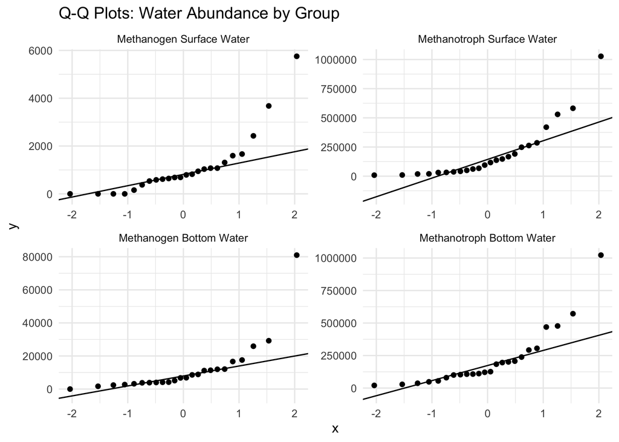

```r
# factor solar progress
water_ch4_cyclers_df$solar_progress <- factor(
  water_ch4_cyclers_df$solar_progress,
  levels = c("FPV", "Open"))

# factor depth
water_ch4_cyclers_df$Depth_Class <- factor(
  water_ch4_cyclers_df$Depth_Class,
  levels = c("Surface Water", "Bottom Water"))

# now add interaction column to our df
water_ch4_cyclers_df <- water_ch4_cyclers_df %>%
  mutate(group = interaction(CH4_Cycler, Depth_Class, sep = " ")) %>%
  group_by(Pond, solar_progress, Depth_Class, group, JDate, CH4_Cycler, DNA_ID) %>%
  summarise(
    total_abundance = sum(Abundance, na.rm = TRUE), # total across all samples
    .groups = "drop"
  )


# qq plot to visualize normality
ggplot(water_ch4_cyclers_df, aes(sample = total_abundance)) +
  stat_qq() +
  stat_qq_line() +
  facet_wrap(~ group, scales = "free") +
  theme_minimal() +
  labs(title = "Q-Q Plots: Water Abundance by Group")
```

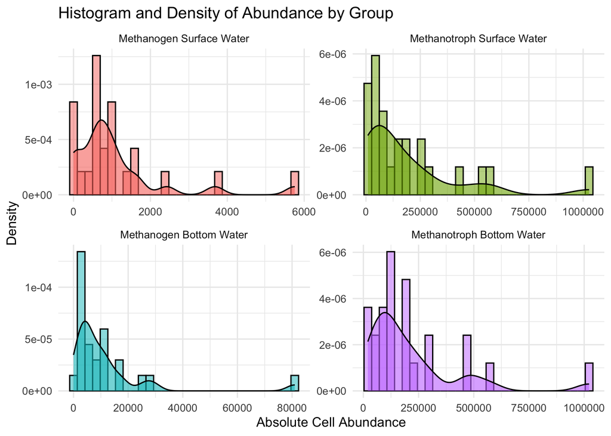

```r
# lets plot density histogram by group too
ggplot(water_ch4_cyclers_df, aes(x = total_abundance, fill = group)) +
  geom_histogram(aes(y = ..density..), bins = 30, alpha = 0.5, color = "black") +
  geom_density(alpha = 0.6) +
  facet_wrap(~ group, scales = "free") +
  theme_minimal() +
  labs(title = "Histogram and Density of Abundance by Group",
       x = "Absolute Cell Abundance",
       y = "Density") +
  theme(legend.position = "none")
```

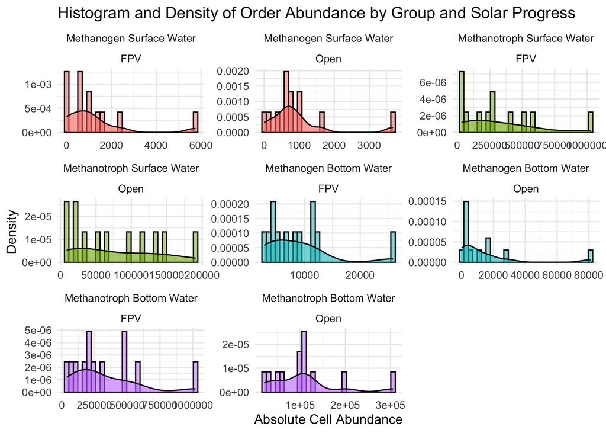

```r
# now lets plot density histogram by further facetting by treatment
ggplot(water_ch4_cyclers_df, aes(x = total_abundance, fill = group)) +
  geom_histogram(aes(y = ..density..), bins = 30, alpha = 0.5, color = "black") +
  geom_density(alpha = 0.6) +
  facet_wrap(~ group + solar_progress, scales = "free") +
  theme_minimal() +
  labs(title = "Histogram and Density of Order Abundance by Group and Solar Progress",
       x = "Absolute Cell Abundance",
       y = "Density") +
  theme(legend.position = "none")
```

```r
# shapiro test
water_ch4_cyclers_df %>%
  group_by(group) %>%
  summarise(
    shapiro_p = shapiro.test(total_abundance)$p.value,
    n = n()
  )
```

```
## # A tibble: 4 × 3
##   group                        shapiro_p     n
##   <fct>                            <dbl> <int>
## 1 Methanogen Surface Water   0.0000202      24
## 2 Methanotroph Surface Water 0.0000304      24
## 3 Methanogen Bottom Water    0.000000400    24
## 4 Methanotroph Bottom Water  0.0000474      24
```

Based on our data with the qq plots we see that the points more or less fit the line. but when we investigate further with the density histograms, the data lacks a clear unimodal distribution. Now, let’s check this out further with a Shapiro-Wilk test. When we run our Shapiro-Wilk test to also test for a normal distribution if p > 0.05 the data is likely normal but if p < 0.05 then the data is not normal.